# Ford Gobike Trip Data Exploration

## By Satvinder Kaur

## Investigation Overview

In this investigation, I wanted to look at how the given features in Ford Gobike trip data can affect the trip durations. I also wanted to see different trends in number of trips over the period of time. My main focus was on these features: Trip duration, User type, Start Day, month and hour of a trip.

## Dataset Overview

This dataset contains information about Ford Gobike trips from 2017. Ford Gobike is now known as Bay wheels which is a regional public bicycle sharing system in San Francisco Bay Area, California. There are 519,700 rows in this dataset each representing an individual bike trip with 16 features. The features used in this analysis are as follows:

- **duration_sec** - Trip duration in seconds
- **user_type** - User type (Subscriber or Customer)
- **month** - Month when trip started
- **day** - Day of week when trip started
- **hour** - Hour of a day when trip started

## Distribution of Trip Durations

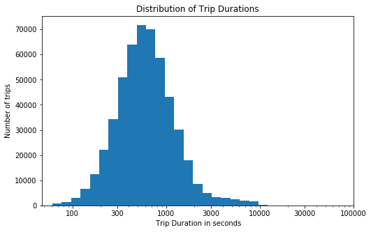

```python
# Trip duration distribution in log-scaled plot

plt.figure(figsize=[8, 5])
log_binsize = 0.1
bins = 10 ** np.arange(np.log10(df.duration_sec.min()), np.log10(df.duration_sec.max())+log_binsize, log_binsize)

ticks = [100, 300, 1000, 3000, 10000, 30000, 100000]
ticks_labels = ['{}'.format(v) for v in ticks]

plt.hist(data = df, x= 'duration_sec', bins = bins);
plt.xscale('log')

plt.xticks(ticks, ticks_labels)
plt.title('Distribution of Trip Durations')
plt.xlabel(' Trip Duration in seconds')
plt.ylabel('Number of trips');
```

## Distribution of User Types

- This data set have two different user types of Gobike services, Subscribers and Customers.
- Most of the users are subscribers who use Gobike service on regular basis.

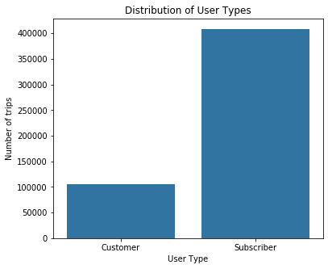

```python
# Standard bar plot for categorical variable user type
plt.figure(figsize=[6, 5])
base_color = sb.color_palette()[0]

sb.countplot(data= df, x ='user_type', color = base_color);

plt.title('Distribution of User Types')
plt.ylabel('Number of trips')
plt.xlabel('User Type');
```

## Effect of User Types on Trip Duration

- Subscribers takes less time to complete the trip compared to customers.
- This could be because subscribers are regular users.

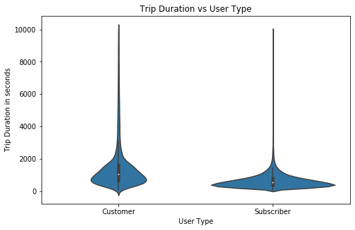

```python
# Using violin plot
plt.figure(figsize=[8, 5])
base_color = sb.color_palette()[0]
sb.violinplot(data=df ,x='user_type',y='duration_sec', color=base_color);
plt.title('Trip Duration vs User Type')
plt.ylabel('Trip Duration in seconds')
plt.xlabel('User Type');
```

## Effect of User Types on Trip Duration on particular Day of a week

- The effect of user types on trip duration is constant throughout a week.
- The day of a week when the trip started does not seem to much affect the trip duration.
- Subscribers take lesser time to complete their trips throughout a week compared to customers.
- Customers more often have longer trip durations compare to subscribers .

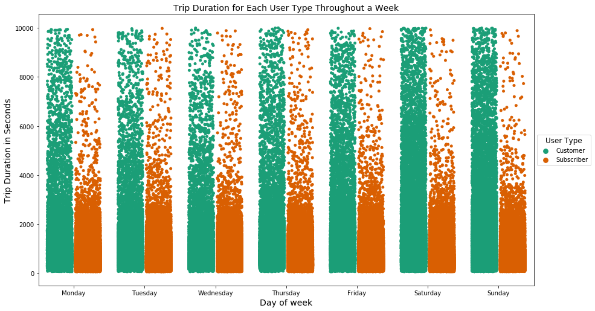

```python
# Using stripplot for trip duration and day by user type
plt.figure(figsize=[14.70, 8.27])
sb.stripplot(data = df, x = 'day', y = 'duration_sec', hue = 'user_type', jitter = 0.35, dodge = True, palette ='Dark2');
plt.xlabel('Day of week', fontsize=14)
plt.ylabel('Trip Duration in Seconds', fontsize=14)
plt.title('Trip Duration for Each User Type Throughout a Week', fontsize=14);
plt.legend(loc='center left', bbox_to_anchor =(1, 0.5), title = "User Type", title_fontsize = 12);
```

## Trends of Gobike trips taken on weekdays vs weekends

- The distribution for Gobike trips on weekdays is bimodal with two peaks around 7am to 9am and 4pm to 6pm indicating that Gobike services were used for work/school commute.
- The distribution for weekend Gobike trips is unimodal with a peak at 1pm, and most of the trips were taken in the middle of the day from 10am to 6pm.
- Most late night trips i.e after 11pm till 3am early morning are taken on weekends.

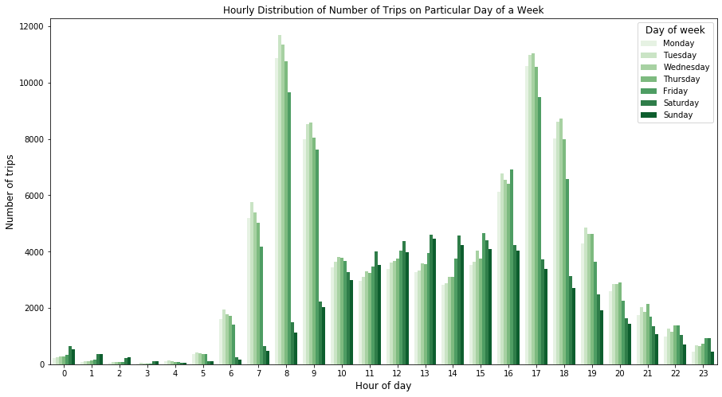

```python
# Using clustered bar charts
plt.figure(figsize=[15, 8])
sb.countplot(data=df, x='hour', hue='day', palette = 'Greens');
plt.xlabel('Hour of day', fontsize = 12)
plt.ylabel('Number of trips', fontsize = 12)
plt.title('Hourly Distribution of Number of Trips on Particular Day of a Week', fontsize = 12)
plt.legend(title = "Day of week", title_fontsize = 12);
```

## Trends of Gobike trips taken per hour during a week for subscribers and customers

- Subscribers use the bike service mostly during weekdays between 7am to 9am and 4pm to 6pm, while customers use bike service mostly on weekends from 10am to 5pm.

[figure not shown]

```python
# Using separte heatmaps for subscribers and customers
plt.figure(figsize=[14.70, 8.27])
plt.suptitle('Hourly distribution of Gobike trips during a week for subscribers and customers')

plt.subplot(2, 1, 1)
df_subscribers = df.query('user_type == "Subscriber"')
s_counts = df_subscribers.groupby(['day', 'hour']).size()
s_counts = s_counts.reset_index(name='count')
s_counts = s_counts.pivot(index='day', columns='hour', values='count')
sb.heatmap(s_counts, cmap="Blues");
plt.title('Subscriber', loc='left', fontsize = 14)
plt.xlabel('Hour of day')
plt.ylabel('Day of week');

plt.subplot(2, 1, 2)
df_customers = df.query('user_type == "Customer"')
c_counts = df_customers.groupby(['day', 'hour']).size()
c_counts = c_counts.reset_index(name='count')
c_counts = c_counts.pivot(index='day', columns='hour', values='count')
sb.heatmap(c_counts, cmap="Blues")
plt.title('Customer', loc='left', fontsize = 14);
plt.xlabel('Hour of day')
plt.ylabel('Day of week');
```